# Comparing three groups

2021-09-24

Supplementary R code for reproducing the examples in the paper ``Comparing three groups’’.

## Set up

Install and load the required R packages:

```r
require("dobson") || install.packages("dobson")
require("tidyr") || install.packages("tidyr")
require("DescTools") || install.packages("DescTools")
require("ggplot2") || install.packages("ggplot2")
require("ggpubr") || install.packages("ggpubr")
require("multcomp") || install.packages("multcomp")
require("multtest") || install.packages("multtest")
require("kableExtra") || install.packages("kableExtra")
require("effects") || install.packages("effects")
require("repmis") || install.packages("repmis")
```

## One-way ANOVA example

This example is taken from Dobson’s (1983) book, Section 7.

Genetically similar seeds are randomly assigned to be raised either under standard conditions (**control**) or in two different nutritionally enriched environments (**treatment A** and **treatment B**). After a predetermined period all plants are harvested, dried and weighed. The results, expressed as dried weight in grams, for samples of $10$ plants from each group are given in following Table.

| Control | TreatmentA | TreatmentB |
| --- | --- | --- |
| 4.17, 5.58, 5.18, 6.11, 4.50, 4.61, 5.17, 4.53, 5.33, 5.14 | 4.81, 4.17, 4.41, 3.59, 5.87, 3.83, 6.03, 4.89, 4.32, 4.69 | 6.31, 5.12, 5.54, 5.50, 5.37, 5.29, 4.92, 6.15, 5.80, 5.26 |

We assume the linear model
$$Y_{u,i} = \mu_i + \varepsilon_{u,i}, \qquad i=1,2,3, \quad u=1,\ldots,10,$$
where $Y_{u,i}$ is the response (dried weight) for unit $u$ in group $i$ ($i=1$ for control, $i=2$ for treatment A and $i=3$ for treatment B), and $\varepsilon_{u,i} \stackrel{\mathrm{iid}}{\sim} N(0,\sigma^2)$. We are interested in testing the global null hypothesis that all three group means are equal, i.e. $H_{123}: \mu_1 = \mu_2=\mu_3$, and the three null hypotheses about pairwise comparisons between groups, i.e. $H_{12}: \mu_1=\mu_2$, $H_{13}: \mu_1=\mu_3$ and $H_{23}: \mu_2=\mu_3$.

To get estimates $\hat{\mu}_1$, $\hat{\mu}_2$, $\hat{\mu}_3$ and $\hat{\sigma}^2$:

```r
fit <- lm(weight ~ group -1, plant.dried)
fit$coefficients
```

```
#>    groupControl groupTreatmentA groupTreatmentB
#>           5.032           4.661           5.526
```

```r
summary(fit)$sigma^2
```

```
#> [1] 0.3885959
```

Partial $F$-test unadjusted $p$-values for $H_{12}$, $H_{13}$ and $H_{23}$:

```r
fit_12 <- lm(weight ~ I(group=="TreatmentB"), plant.dried)
p_12 <- anova(fit_12,fit)[2,"Pr(>F)"]
p_12
```

```
#> [1] 0.1943879
```

```r
fit_13 <- lm(weight ~ I(group=="TreatmentA"), plant.dried)
p_13 <- anova(fit_13,fit)[2,"Pr(>F)"]
p_13
```

```
#> [1] 0.08768168
```

```r
fit_23 <- lm(weight ~ I(group=="Control"), plant.dried)
p_23 <- anova(fit_23,fit)[2,"Pr(>F)"]
p_23
```

```
#> [1] 0.004459236
```

Tukey’s HSD adjusted $p$-values for $H_{12}$, $H_{13}$ and $H_{23}$:

```r
p_tuk <- TukeyHSD(aov(weight ~ group, data = plant.dried))$group[,'p adj']
p_tuk
```

```
#>    TreatmentA-Control    TreatmentB-Control TreatmentB-TreatmentA
#>            0.39087114            0.19799599            0.01200642
```

Dunnett adjusted $p$-values for $H_{12}$ and $H_{13}$

```r
p_dun <- DunnettTest(weight ~ factor(group), plant.dried, control="Control")$Control[,'pval']
p_dun
```

```
#> TreatmentA-Control TreatmentB-Control
#>          0.3226957          0.1534859
```

ANOVA F-test (method A), closed Tukey (method B), closed Dunnett (method C) and Gatekeeping (method D) $p$-values for $H_{123}$:

```r
fit_123 <- lm(weight ~ 1, plant.dried)
p_A <- anova(fit_123,fit)[2,"Pr(>F)"]
p_A
```

```
#> [1] 0.01590996
```

```r
p_B <- min(p_tuk)
p_B
```

```
#> [1] 0.01200642
```

```r
p_C <- min(p_dun)
p_C
```

```
#> [1] 0.1534859
```

```r
p_D <- p_12
p_D
```

```
#> [1] 0.1943879
```

Adjusted $p$-values for the four hypotheses and the four methods:

```r
adjp <- matrix(NA,nrow=4,ncol=4,
              dimnames = list(c("A", "B", "C", "D"),
                              c("H12", "H13", "H23", "H123")))
adjp["A",] <- pmax(c(p_12,p_13,p_23,p_A),p_A)
adjp["B",] <- pmax(c(p_12,p_13,p_23,p_B),p_B)
adjp["C",] <- pmax(c(p_12,p_13,p_23,p_C),p_C)
adjp["D",] <- pmax(c(p_12,p_13,p_23,p_D),p_D)
adjp
```

```
#>         H12        H13        H23       H123
#> A 0.1943879 0.08768168 0.01590996 0.01590996
#> B 0.1943879 0.08768168 0.01200642 0.01200642
#> C 0.1943879 0.15348586 0.15348586 0.15348586
#> D 0.1943879 0.19438788 0.19438788 0.19438788
```

For method A, add adjusted $p$-values to box-plots:

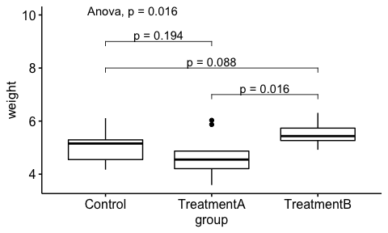

```r
bp <- ggboxplot(plant.dried, x = "group", y = "weight")
stats <- compare_means(weight ~ group, data = plant.dried, method = "t.test")
stats$p.adj <- round(adjp["A",-4],3)
bp + stat_compare_means(method = "anova", label.y = 10) +
  stat_pvalue_manual(stats, label = "p = {p.adj}", y.position =   c(9, 8, 7))
```

#### Alternative analyses

The methods A, B, C and D are not tied to $F$-tests, and naturally generalize to other tests. For example, if we believe that variances may differ between groups when the means do, we would prefer a two-sample $t$-test over the $F$-test for the pairwise hypotheses. By replacing partial F-tests by two-samples $t$ tests, we obtain

```r
p_12 <- stats$p[1]
p_13 <- stats$p[2]
p_23 <- stats$p[3]
adjp["A",] <- pmax(c(p_12,p_13,p_23,p_A),p_A)
adjp["B",] <- pmax(c(p_12,p_13,p_23,p_B),p_B)
adjp["C",] <- pmax(c(p_12,p_13,p_23,p_C),p_C)
adjp["D",] <- pmax(c(p_12,p_13,p_23,p_D),p_D)
adjp
```

```
#>         H12        H13        H23       H123
#> A 0.2503825 0.04789926 0.01590996 0.01590996
#> B 0.2503825 0.04789926 0.01200642 0.01200642
#> C 0.2503825 0.15348586 0.15348586 0.15348586
#> D 0.2503825 0.19438788 0.19438788 0.19438788
```

resulting in the rejection of $H_{123}$, $H_{13}$ and $H_{23}$ at $\alpha=5\%$ for methods A and B.Here method A is Fisher’s LSD.

We could also use methods A, B, C and D in a permutation framework. A standard choice is to consider non-standardized test statistics $T_{ij} = (\hat{\mu}_i - \hat{\mu}_j)^2$ for testing $H_{ij}$, and $T_{123} = T_{12}+T_{23}+ T_{13}$, $\tilde{T} = \max(T_{12}, T_{13},T_{23})$, $\tilde{T}_{1}=\max(T_{12}, T_{13})$ and $T_{12}$ for testing $H_{123}$ in methods A, B, C and D, respectively.

The construction of the permutation null distribution for each test statistic proceeds as follows. The observations of the groups are pooled, and the test statistic is recalculated for every permutation of the group labels.

Permutation tests of $H_{123}$ uses a global permutation distribution, constructed by permuting the observations of all three groups.

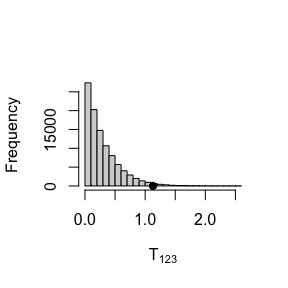

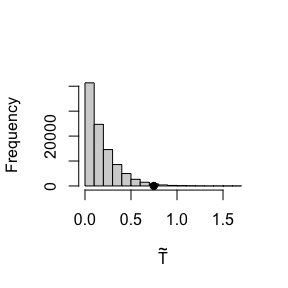

```r
labels <- factor(plant.dried$group, labels=0:2)
labels <- as.numeric(levels(labels))[labels]
B = 10^5
labels.perm <- mt.sample.label(labels, test="f", B=B)
c12 <- ( (labels.perm + 2) %% 3 ) -1
c13 <- labels.perm - 1
c23 <- ( (labels.perm + 1) %% 3 ) -1
y <- plant.dried$weight
n <- 10
stats.perm <- rbind(
( y %*% t(c12) / n )^2,
( y %*% t(c13) / n )^2,
( y %*% t(c23) / n )^2
)
hist(colSums(stats.perm), main="", xlab=expression(T[123]), xatx="n")
points(sum(stats.perm[,1]),0, pch=19)
hist(apply(stats.perm,2,max), main="", xlab=expression( tilde(T) ) )
points(max(stats.perm[,1]),0, pch=19)
```

The permutation $p$-value is calculated as the proportion of permutations where the test statistic is greater than or equal to the value computed on the original data.

```r
p_A <- mean( colSums(stats.perm) >= sum(stats.perm[,1]) )
p_A
```

```
#> [1] 0.01668
```

```r
p_B <- mean( apply(stats.perm,2,max) >= max(stats.perm[,1]) )
p_B
```

```
#> [1] 0.01136
```

```r
p_C <- mean( apply(stats.perm[-3,],2,max) >= max(stats.perm[-3,1]) )
p_C
```

```
#> [1] 0.20692
```

The permutation version of the ANOVA F-test can also be obtained by

```r
t_123 <- mt.sample.teststat(y, labels, B=B, test="f")
p_A <- mean( t_123 >= t_123[1] )
p_A
```

```
#> [1] 0.01668
```

Permutation tests of $H_{ij}$ use a local permutation distribution, constructed by permuting the observations of groups $i$ and $j$.

```r
t_12 <- (mt.sample.teststat(y[labels!=2],labels[labels!=2], B=0, test="t.equalvar") ) ^2
```

```
#>
#> We're doing 184756 complete permutations
```

```r
p_12 <- mean(t_12 >= t_12[1])
p_12
```

```
#> [1] 0.2471801
```

```r
t_13 <- (mt.sample.teststat(y[labels!=1],labels[labels!=1]=="2", B=0, test="t.equalvar") ) ^2
```

```
#>
#> We're doing 184756 complete permutations
```

```r
p_13 <- mean(t_13 >= t_13[1])
p_13
```

```
#> [1] 0.04797679
```

```r
t_23 <- (mt.sample.teststat(y[labels!=0],labels[labels!=0]=="2", B=0, test="t.equalvar") ) ^2
```

```
#>
#> We're doing 184756 complete permutations
```

```r
p_23 <- mean(t_23 >= t_23[1])
p_23
```

```
#> [1] 0.00853017
```

Adjusted $p$-values with permutation tests for the four hypotheses and the four methods:

```r
p_D <- p_12
adjp["A",] <- pmax(c(p_12,p_13,p_23,p_A),p_A)
adjp["B",] <- pmax(c(p_12,p_13,p_23,p_B),p_B)
adjp["C",] <- pmax(c(p_12,p_13,p_23,p_C),p_C)
adjp["D",] <- pmax(c(p_12,p_13,p_23,p_D),p_D)
adjp
```

```
#>         H12        H13       H23      H123
#> A 0.2471801 0.04797679 0.0166800 0.0166800
#> B 0.2471801 0.04797679 0.0113600 0.0113600
#> C 0.2471801 0.20692000 0.2069200 0.2069200
#> D 0.2471801 0.24718006 0.2471801 0.2471801
```

Rank tests can be obtained as a special case of permutation tests by replacing the observations with their ranks.

```r
r <- rank(y, ties.method = "average")
ranks.perm <- rbind(
( r %*% t(c12) / n )^2,
( r %*% t(c13) / n )^2,
( r %*% t(c23) / n )^2
)
p_A <- mean( colSums(ranks.perm) >= sum(ranks.perm[,1]) )
p_B <- mean( apply(ranks.perm,2,max) >= max(ranks.perm[,1]) )
p_C <- mean( apply(ranks.perm[-3,],2,max) >= max(ranks.perm[-3,1]) )
```

Kruskal-Wallis test can also be obtained by

```r
w_123 <- mt.sample.teststat(y, labels, B=B, test="f", nonpara = "y")
p_A <- mean( w_123 >= w_123[1] )
p_A
```

```
#> [1] 0.01442
```

Wilcoxon-Mann-Whitney tests are obtained by

```r
w_12 <- (mt.sample.teststat(y[labels!=2],labels[labels!=2], B=0, test="wilcoxon"))^2
```

```
#>
#> We're doing 184756 complete permutations
```

```r
p_12 <- mean(w_12 >= w_12[1])
w_13 <- (mt.sample.teststat(y[labels!=1],labels[labels!=1]=="2", B=0, test="wilcoxon"))^2
```

```
#>
#> We're doing 184756 complete permutations
```

```r
p_13 <- mean(w_13 >= w_13[1])
w_23 <- (mt.sample.teststat(y[labels!=0],labels[labels!=0]=="2", B=0, test="wilcoxon"))^2
```

```
#>
#> We're doing 184756 complete permutations
```

```r
p_23 <- mean(w_23 >= w_23[1])
p_D <- p_12
```

Adjusted $p$-values with rank tests for the four hypotheses and the four methods:

```r
adjp["A",] <- pmax(c(p_12,p_13,p_23,p_A),p_A)
adjp["B",] <- pmax(c(p_12,p_13,p_23,p_B),p_B)
adjp["C",] <- pmax(c(p_12,p_13,p_23,p_C),p_C)
adjp["D",] <- pmax(c(p_12,p_13,p_23,p_D),p_D)
adjp
```

```
#>         H12        H13       H23      H123
#> A 0.1967568 0.06301284 0.0144200 0.0144200
#> B 0.1967568 0.06301284 0.0106300 0.0106300
#> C 0.1967568 0.16581000 0.1658100 0.1658100
#> D 0.1967568 0.19675680 0.1967568 0.1967568
```

## ANCOVA example

As with ANOVA, we are interested in comparing means for groups defined by a factor while controlling for the effects of other covariates that are not of primary interest. The following table displays data from Winer (1971), discussed in Dobson (1983).

| Group A y | Group A x | Group B y | Group B x | Group C y | Group C x |
| --- | --- | --- | --- | --- | --- |
| 6 | 3 | 8 | 4 | 6 | 3 |
| 4 | 1 | 9 | 5 | 7 | 2 |
| 5 | 3 | 7 | 5 | 7 | 2 |
| 3 | 1 | 9 | 4 | 7 | 3 |
| 4 | 2 | 8 | 3 | 8 | 4 |
| 3 | 1 | 5 | 1 | 5 | 1 |
| 6 | 4 | 7 | 2 | 7 | 4 |

The response $y$ is the achievement score, the levels A, B and C of the group factor represent three different training methods, and the covariate $x$ is the aptitude score measured before training commenced. We want to compare the training methods, taking into account differences in initial aptitude between the three groups of subjects.

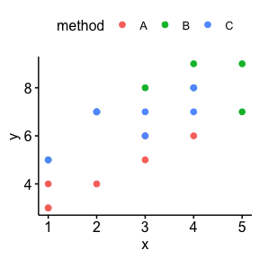

```r
achievement$method <- factor(achievement$method)
ggscatter(achievement, x="x", y="y", color = "method")
```

We assume that the response in group $i$ is normally distributed with mean $\mu_i(x)$ and variance $\sigma^2$, with
$$\mu_i(x) = \gamma + \tau_i + \beta (x - \bar{x})$$
where $\gamma$ is the common mean, $\tau_i$ is the $i$th group effect such that $\sum_i \tau_i =0$, $\beta$ is the regression slope and $\bar{x}$ is the average covariate value, with $i=1,2,3$ for group A,B,C, respectively.

Estimates $\hat\mu_1(\bar{x}_1)$, $\hat\mu_2(\bar{x}_2)$ and $\hat\mu_3(\bar{x}_3)$:

```r
fit <- lm(y ~ x + method, data = achievement)
effect("method", fit)

 method effect
method
       A        B        C
4.888435 7.076190 6.749660
```

Graph of the fitted model:

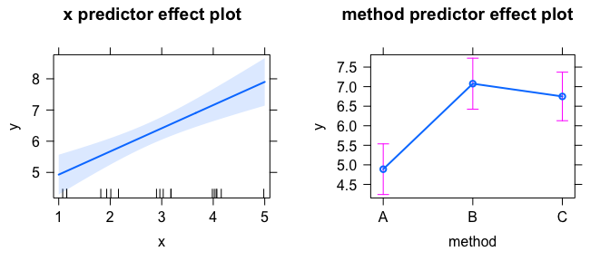

```r
plot(predictorEffects(fit))
```

Let $Y$ and $X$ denote the response vector and the design matrix, respectively, and let $\hat{\theta} = (X'X)^{-1}XY$ be the least square estimator.

Least square estimates $\hat{\theta}$ and $\hat{\sigma}^2$:

```r
X <- model.matrix(fit)
df <- summary(fit)$df[2]
theta <- coef(fit)
theta
```

```
#> (Intercept)           x     methodB     methodC
#>   2.8367347   0.7428571   2.1877551   1.8612245
```

```r
s2 <- summary(fit)$sigma^2
s2
```

```
#> [1] 0.6060024
```

We can use the multcomp package to calculate the test statistics and find their distribution.

Matrix $K$ specifying pairwise contrasts of factor levels:

```r
tuk <- glht(fit,linfct=mcp(method="Tukey"))
K <- tuk$linfct
K
      (Intercept) x methodB methodC
B - A           0 0       1       0
C - A           0 0       0       1
C - B           0 0      -1       1
attr(,"type")
[1] "Tukey"
```

Estimated differences $K\hat{\theta} = \left(\begin{array}{c} \hat{\mu}_2(\bar{x}_2) - \hat{\mu}_1(\bar{x}_1)\\ \hat{\mu}_3(\bar{x}_3) - \hat{\mu}_1(\bar{x}_1)\\ \hat{\mu}_3(\bar{x}_3) - \hat{\mu}_2(\bar{x}_2)\\ \end{array}\right)$

```r
K %*% theta
```

```
#>             [,1]
#> B - A  2.1877551
#> C - A  1.8612245
#> C - B -0.3265306
```

and estimated covariance matrix $\hat{\Sigma} = \hat{\sigma}^2 K(X'X)^{-1}K'$

```r
S <- s2 * K %*% solve(crossprod(X)) %*% t(K)
S
```

```
#>            B - A      C - A       C - B
#> B - A  0.2065355 0.10141265 -0.10512287
#> C - A  0.1014126 0.17973949  0.07832684
#> C - B -0.1051229 0.07832684  0.18344971
```

Unadjusted $p$-values $p_{12}$, $p_{13}$ and $p_{23}$

```r
p_raw <- pf( (K %*% theta)^2 / diag(S), df1 = 1, df2 = df, lower.tail = F)
p_12 <- p_raw[1]
p_12
```

```
#> [1] 0.0001620169
```

```r
p_13 <- p_raw[2]
p_13
```

```
#> [1] 0.0003995625
```

```r
p_23 <- p_raw[3]
p_23
```

```
#> [1] 0.456288
```

Tukey’s HSD adjusted $p$-values $\tilde{p}^{Tuk}_{12}$, $\tilde{p}^{Tuk}_{13}$ and $\tilde{p}^{Tuk}_{23}$ :

```r
p_tuk <- summary(tuk)$test$pvalues[1:3]
p_tuk
```

```
#> [1] 0.0004274782 0.0011832849 0.7302152807
```

Dunnett adjusted $p$-values $\tilde{p}^{Dun}_{12}$ and $\tilde{p}^{Dun}_{13}$

```r
dun <- glht(fit,linfct=mcp(method="Dunnett"))
p_dun <- summary(dun)$test$pvalues[1:2]
p_dun
```

```
#> [1] 0.0003111268 0.0007633035
```

ANCOVA F-test (method A), closed Tukey (method B), closed Dunnett (method C) and Gatekeeping (method D) $p$-values for $H_{123}$:

```r
fit_123 <- lm(y ~ x, achievement)
p_A <- anova(fit_123,fit)[2,"Pr(>F)"]
p_B <- min(p_tuk)
p_C <- min(p_dun)
p_D <- p_12
```

Adjusted $p$-values for the four hypotheses and the four methods:

```r
adjp <- matrix(NA,nrow=4,ncol=4,
              dimnames = list(c("A", "B", "C", "D"),
                              c("H12", "H13", "H23", "H123")))
adjp["A",] <- pmax(c(p_12,p_13,p_23,p_A),p_A)
adjp["B",] <- pmax(c(p_12,p_13,p_23,p_B),p_B)
adjp["C",] <- pmax(c(p_12,p_13,p_23,p_C),p_C)
adjp["D",] <- pmax(c(p_12,p_13,p_23,p_D),p_D)
adjp
```

```
#>            H12          H13      H23         H123
#> A 0.0002578664 0.0003995625 0.456288 0.0002578664
#> B 0.0004274782 0.0004274782 0.456288 0.0004274782
#> C 0.0003111268 0.0003995625 0.456288 0.0003111268
#> D 0.0001620169 0.0003995625 0.456288 0.0001620169
```

## Four-group example

Jakob et al. (2019) collected a dataset from 847 subjects to study the relation between Harry Potter Houses and personality traits. The raw data can be found at https://osf.io/rtf74/.

In this analysis, the outcome variable is the Machiavellianism score, as measured by the Dark Triad Questionnaire (Jones and Paulhus, 2014), and the affiliation to four Houses of Hogwarts - Gryffindor, Hufflepuff, Ravenclaw, or Slytherin - is determined by the Sorting Hat Quiz, available on https://www.pottermore.com.

```r
rm(list=ls())
set.seed(123)
source_data("https://github.com/aldosolari/comparing3groups/blob/main/Harry4.RData?raw=true")
```

```
#> SHA-1 hash of the downloaded data file is:
#> 748c8a18d72cdbc1b94960145e0257bc23e56b2f
#> [1] "Harry4"
```

```r
table(Harry4$group)
```

```
#>
#> Gryffindor Hufflepuff  Ravenclaw  Slytherin
#>         43         36         42         24
```

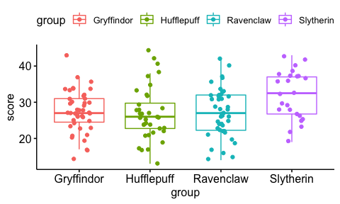

```r
ggboxplot(Harry4, x = "group", y = "score", col="group", add = "jitter")
```

To get estimates $\hat{\mu}_1$, $\hat{\mu}_2$, $\hat{\mu}_3$ and $\hat{\mu}_4$:

```r
levels(Harry4$group) <- 1:4
fit <- lm(score ~ group -1, Harry4)
fit$coefficients
```

```
#>   group1   group2   group3   group4
#> 27.48837 26.91667 27.28571 32.04167
```

To compute unadjusted $p$-values for $H_{12}$, $H_{13}$, $H_{14}$, $H_{23}$, $H_{24}$ and $H_{34}$:

```r
tuk <- glht(fit,linfct=mcp(group="Tukey"))
p_pair = summary(tuk, test=adjusted("none"))$test$pvalues
round(p_pair,4)
```

```
#>  2 - 1  3 - 1  4 - 1  3 - 2  4 - 2  4 - 3
#> 0.7015 0.8875 0.0075 0.8056 0.0037 0.0055
```

Define the 14 hypotheses and the inclusion relationship between each elementary hypothesis and its ancestors:

```r
hyp = list(`1234` = 1:4,
           `123` = 1:3,
           `124` = c(1:2,4),
           `134` = c(1,3:4),
           `234` = 2:4,
           `12_34` = list(1:2,3:4),
           `13_24` = list(c(1,3),c(2,4)),
           `14_23` = list(c(1,4),2:3),
           `12` = 1:2,
           `13` = c(1,3),
           `14` = c(1,4),
           `23` = 2:3,
           `24` = c(2,4),
           `34` = 3:4)
subhyp <- sapply(hyp[c("12","13","14","23","24","34")],
            function(y)
            sapply(hyp, function(x) ifelse(any(lengths(x)<2),
                               all(y %in% x),
                               list(y) %in% x)))
```

To compute adjusted $p$-values for $H_{12}$, $H_{13}$, $H_{14}$, $H_{23}$, $H_{24}$ and $H_{34}$ for classic closed testing with partial $F$-tests:

```r
rawp_A <- vector("numeric", length = length(hyp))
names(rawp_A) <- names(hyp)
rawp_A["1234"] <- anova(lm(score ~ 1, Harry4),fit)[2,"Pr(>F)"]
rawp_A[c("123","124","134","234")] <- sapply(4:1, function(i)
                      anova(lm(score ~ I(group==i), Harry4),fit)[2,"Pr(>F)"] )
anova_12_34 <- glht(fit, linfct=c("group1 - group2 = 0",
                                  "group3 - group4 = 0"))
rawp_A["12_34"] <-summary(anova_12_34, test=Ftest())$test$pvalue
anova_13_24 <- glht(fit, linfct=c("group1 - group3 = 0",
                                  "group2 - group4 = 0"))
rawp_A["13_24"] <-summary(anova_13_24, test=Ftest())$test$pvalue
anova_14_23 <- glht(fit, linfct=c("group1 - group4 = 0",
                                  "group2 - group3 = 0"))
rawp_A["14_23"] <-summary(anova_14_23, test=Ftest())$test$pvalue
rawp_A[c("12","13","14","23","24","34")] <- p_pair
adjp_A <- apply(subhyp, 2, function(x) max(rawp_A[x]) )
```

Closed Tukey adjusted $p$-values:

```r
rawp_B <- vector("numeric", length = length(hyp))
names(rawp_B) <- names(hyp)
rawp_B["1234"] <- min(summary(tuk)$test$pvalues)
tuk_123 <- glht(fit, linfct=c("group1 - group2 = 0",
                              "group1 - group3 = 0",
                              "group2 - group3 = 0"))
rawp_B["123"] <- min(summary(tuk_123)$test$pvalues)
tuk_124 <- glht(fit, linfct=c("group1 - group2 = 0",
                              "group1 - group4 = 0",
                              "group2 - group4 = 0"))
rawp_B["124"] <- min(summary(tuk_124)$test$pvalues)
tuk_134 <- glht(fit, linfct=c("group1 - group3 = 0",
                              "group1 - group4 = 0",
                              "group3 - group4 = 0"))
rawp_B["134"] <- min(summary(tuk_134)$test$pvalues)
tuk_234 <- glht(fit, linfct=c("group2 - group3 = 0",
                              "group2 - group4 = 0",
                              "group3 - group4 = 0"))
rawp_B["234"] <- min(summary(tuk_234)$test$pvalues)
tuk_12_34 <- glht(fit, linfct=c("group1 - group2 = 0",
                                "group3 - group4 = 0"))
rawp_B["12_34"] <- min(summary(tuk_12_34)$test$pvalues)
tuk_13_24 <- glht(fit, linfct=c("group1 - group3 = 0",
                                "group2 - group4 = 0"))
rawp_B["13_24"] <- min(summary(tuk_13_24)$test$pvalues)
tuk_14_23 <- glht(fit, linfct=c("group1 - group4 = 0",
                                "group2 - group3 = 0"))
rawp_B["14_23"] <- min(summary(tuk_14_23)$test$pvalues)
rawp_B[c("12","13","14","23","24","34")] <- p_pair
adjp_B <- apply(subhyp, 2, function(x) max( rawp_B[x]) )
```

Closed Dunnett adjusted $p$-values:

```r
rawp_C <- vector("numeric", length = length(hyp))
names(rawp_C) <- names(hyp)
dun <- glht(fit, linfct=c("group4 - group1 = 0",
                          "group4 - group2 = 0",
                          "group4 - group3 = 0"))
rawp_C["1234"] <- min(summary(dun)$test$pvalues)
rawp_C["123"] <- rawp_A["123"]
dun_124 <- glht(fit, linfct=c("group4 - group1 = 0",
                              "group4 - group2 = 0"))
rawp_C["124"] <- min(summary(dun_124)$test$pvalues)
dun_134 <- glht(fit, linfct=c("group4 - group1 = 0",
                              "group4 - group3 = 0"))
rawp_C["134"] <- min(summary(dun_134)$test$pvalues)
dun_234 <- glht(fit, linfct=c("group4 - group3 = 0",
                              "group4 - group2 = 0"))
rawp_C["234"] <- min(summary(dun_234)$test$pvalues)
rawp_C[c("14_23","13_24","12_34")] <- rawp_A[c("14","24","34")]
rawp_C[c("12","13","14","23","24","34")] <- p_pair
adjp_C <- apply(subhyp, 2, function(x) max( rawp_C[x]) )
```

Gatekeeping adjusted $p$-values:

```r
rawp_D <- vector("numeric", length = length(hyp))
names(rawp_D) <- names(hyp)
rawp_D[c("1234",
         "123","124","134","234",
         "12_34","13_24","14_23")] <- rawp_A[c("24",
                                               "12","24","14","24",
                                               "34","24","14")]
rawp_D[c("12","13","14","23","24","34")] <- p_pair
adjp_D <- apply(subhyp, 2, function(x) max(rawp_D[x]) )
```

Adjusted $p$-values for the six hypotheses and four methods

```r
adjp <- matrix(rbind(adjp_A, adjp_B, adjp_C, adjp_D),nrow=4,ncol=6,
               dimnames = list(c("A", "B", "C","D"),names(p_pair)))
round(adjp,4)
```

```
#>    2 - 1  3 - 1  4 - 1  3 - 2  4 - 2  4 - 3
#> A 0.9279 0.9279 0.0269 0.9279 0.0155 0.0194
#> B 0.9219 0.9219 0.0190 0.9219 0.0190 0.0190
#> C 0.9279 0.9279 0.0101 0.9279 0.0101 0.0101
#> D 0.7015 0.8875 0.0075 0.8056 0.0037 0.0075
```

Compare to Tukey’s HSD adjusted $p$-values:

```r
adjp_tuk = c(summary(tuk)$test$pvalues)
names(adjp_tuk) <- rownames(summary(tuk)$linfct)
round(adjp_tuk,4)
```

```
#>  2 - 1  3 - 1  4 - 1  3 - 2  4 - 2  4 - 3
#> 0.9805 0.9990 0.0369 0.9947 0.0194 0.0276
```

Compare to Dunnett’s adjusted $p$-values:

```r
adjp_dun = c(summary(dun)$test$pvalues)
names(adjp_dun) <- rownames(summary(dun)$linfct)
round(adjp_dun,4)
```

```
#> group4 - group1 group4 - group2 group4 - group3
#>          0.0196          0.0097          0.0142
```